# PR02 Streaming Services Data

Palina Schneider, Emma Oliver, Ben Glickauf

Thursday, May 11, 2023 @ 01:02 AM

## Setup

### Packages Used

```r
library(tidyverse)
library(skimr)
```

### Background of the Data

Two files containing data about the content of streaming services were downloaded from Kaggle: [Disney+ Movies and TV Shows](https://www.kaggle.com/datasets/shivamb/disney-movies-and-tv-shows) and [TV shows on Netflix, Prime Video, Hulu and Disney+](https://www.kaggle.com/datasets/ruchi798/tv-shows-on-netflix-prime-video-hulu-and-disney). You can read about them there, including variable definitions, sources, when they were created, and other information. Read the two datasets from the `data_raw` folder and use `skim()` to explore their structures.

#### Disney+ Content Dataset

```r
disney_data <- read.csv("~/Projects/Project#2/STT2860S23project2/data_raw/disneypluscontent_2021_11_21.csv")
```

```r
skim(disney_data)
```

Data summary

| Name | disney_data |
| --- | --- |
| Number of rows | 1450 |
| Number of columns | 12 |
| _______________________ |  |
| Column type frequency: |  |
| character | 11 |
| numeric | 1 |
| ________________________ |  |
| Group variables | None |

**Variable type: character**

| skim_variable | n_missing | complete_rate | min | max | empty | n_unique | whitespace |
| --- | --- | --- | --- | --- | --- | --- | --- |
| show_id | 0 | 1 | 2 | 5 | 0 | 1450 | 0 |
| type | 0 | 1 | 5 | 7 | 0 | 2 | 0 |
| title | 0 | 1 | 2 | 79 | 0 | 1450 | 0 |
| director | 0 | 1 | 0 | 51 | 473 | 610 | 0 |
| cast | 0 | 1 | 0 | 112 | 190 | 1194 | 0 |
| country | 0 | 1 | 0 | 137 | 219 | 90 | 0 |
| date_added | 0 | 1 | 0 | 9 | 3 | 168 | 0 |
| rating | 0 | 1 | 0 | 8 | 3 | 10 | 0 |
| duration | 0 | 1 | 5 | 10 | 0 | 158 | 0 |
| listed_in | 0 | 1 | 4 | 49 | 0 | 329 | 0 |
| description | 0 | 1 | 28 | 102 | 0 | 1448 | 0 |

**Variable type: numeric**

| skim_variable | n_missing | complete_rate | mean | sd | p0 | p25 | p50 | p75 | p100 | hist |
| --- | --- | --- | --- | --- | --- | --- | --- | --- | --- | --- |
| release_year | 0 | 1 | 2003.09 | 21.86 | 1928 | 1999 | 2011 | 2018 | 2021 | ▁▁▁▂▇ |

#### Streaming TV Content Dataset

```r
streaming_data <- read.csv("~/Projects/Project#2/STT2860S23project2/data_raw/streamingtvcontent_2021.csv")
```

```r
skim(streaming_data)
```

Data summary

| Name | streaming_data |
| --- | --- |
| Number of rows | 5368 |
| Number of columns | 10 |
| _______________________ |  |
| Column type frequency: |  |
| character | 4 |
| numeric | 6 |
| ________________________ |  |
| Group variables | None |

**Variable type: character**

| skim_variable | n_missing | complete_rate | min | max | empty | n_unique | whitespace |
| --- | --- | --- | --- | --- | --- | --- | --- |
| Title | 0 | 1 | 1 | 77 | 0 | 5368 | 0 |
| Age | 0 | 1 | 0 | 3 | 2127 | 6 | 0 |
| IMDb | 0 | 1 | 0 | 6 | 962 | 79 | 0 |
| Rotten.Tomatoes | 0 | 1 | 6 | 7 | 0 | 85 | 0 |

**Variable type: numeric**

| skim_variable | n_missing | complete_rate | mean | sd | p0 | p25 | p50 | p75 | p100 | hist |
| --- | --- | --- | --- | --- | --- | --- | --- | --- | --- | --- |
| ID | 0 | 1 | 2814.95 | 1672.39 | 1 | 1345.75 | 2788 | 4308.25 | 5717 | ▇▇▇▇▇ |
| Year | 0 | 1 | 2012.63 | 10.14 | 1904 | 2011.00 | 2016 | 2018.00 | 2021 | ▁▁▁▁▇ |
| Netflix | 0 | 1 | 0.37 | 0.48 | 0 | 0.00 | 0 | 1.00 | 1 | ▇▁▁▁▅ |
| Hulu | 0 | 1 | 0.30 | 0.46 | 0 | 0.00 | 0 | 1.00 | 1 | ▇▁▁▁▃ |
| Prime.Video | 0 | 1 | 0.34 | 0.47 | 0 | 0.00 | 0 | 1.00 | 1 | ▇▁▁▁▅ |
| Disney. | 0 | 1 | 0.07 | 0.25 | 0 | 0.00 | 0 | 0.00 | 1 | ▇▁▁▁▁ |

## Analyses

### Clean, Tidy, and Save the Data

#### Dataset #1: Disney+ Data

The Disney+ dataset contains a variable that gives information about the `rating` for each program offering. Convert that variable into a factor that puts the ratings in (roughly) ascending order of age restriction/audience: `TV-Y`, `TV-Y7`, `TV-Y7-FV`, `TV-G`, `G`, `TV-PG`, `PG`, `PG-13`, `TV-14`. Delete the `show_id`, `director`, `cast`, and `description` variables. You should be able to do this all in one piped sequence.

```r
ratings <- disney_data %>%
  mutate(rating = factor(rating, levels = c("TV-Y", "TV-Y7", "TV-Y7-FV", "TV-G", "G", "TV-PG", "PG", "PG-13", "TV-14")))  %>%
  select(c(-show_id, -director, -cast, -description))
```

#### Dataset #2: Streaming TV Data

Perform the following manipulations to tidy the streaming TV data for analysis. You should be able to do this all in one piped sequence.

- Pivot the `Netflix`, `Hulu`, `Prime Video`, and `Disney+` variables into two columns called `Service` (containing the name of the streaming service) and `YesNo` (containing the 0/1 values from the original columns).
- Filter the data set to remove any row where `YesNo == 0` (i.e., a show is *not* on the service).
- Separate the `IMDb` variable to split each show’s actual rating from the maximum possible rating of `10`.
- Convert the show’s actual IMDB rating into a numerical variable and get rid of the column containing `10`.
- Separate the `Rotten Tomatoes` variable to split each show’s actual rating from the maximum possible rating of `100`.
- Convert the show’s actual Rotten Tomatoes rating into a numerical variable and get rid of the column containing `100`.

```r
tv_streaming <- streaming_data %>%
  pivot_longer(cols = c("Netflix", "Hulu", "Prime.Video", "Disney."),
    names_to = "Service",
    values_to = "YesNo") %>%
  filter(YesNo != 0) %>%
  separate(col = IMDb, into = c("IMDBscore", "IMDBmax"), sep = "/") %>%
  select(-IMDBmax) %>%
  mutate(IMDBscore = as.numeric(IMDBscore)) %>%
  separate(col = Rotten.Tomatoes, into = c("rottenscore", "rottenmax"), sep = "/") %>%
  select(-rottenmax) %>%
  mutate(rottenscore = as.numeric(rottenscore))
```

#### Save the Formatted Data Files

Save both data files in a single`.RData` file in the `data_tidy` folder.

```r
save(tv_streaming, ratings, file = "../data_tidy/bothDataFiles.Rmd")
```

### Analysis 1: Disney Content & Release Years

**This analysis uses Data set #1.**

#### Release Years by Program Type—Plot #1

Create a violin plot of `release_year` (x axis) grouped by `type` of program (y axis) for programs on Disney+. Add a box plot inside the violin plot. Re-scale the X axis so that tick marks appear at whole-decade intervals (e.g., 1980, 1990, 2000). Include an informative title and axis labels. Add at least two other types of formatting to enhance the effectiveness and/or appearance of your plot (e.g., themes, colors, etc).

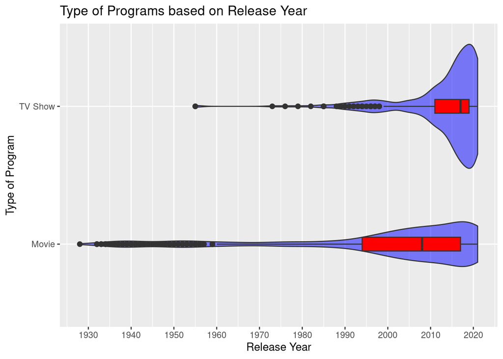

```r
ggplot(ratings, aes(release_year, type)) +
  geom_violin(fill = "Blue", alpha = .5) +
  geom_boxplot(width = .1, fill = "Red", outlier.size = 2) +

  labs(title = "Type of Programs based on Release Year", x = "Release Year", y = "Type of Program") +
  scale_x_continuous(breaks = seq(from = 1920, to = 2030, by = 10))
```

#### Release Years by Program Type—Plot #2

Create a histogram for `release_year` with `type` as a fill variable. Choose a reasonable number of bins or bin width. Re-scale the X axis so that tick marks appear at whole-decade intervals (e.g., 1980, 1990, 2000). Scale the Y axis to have reasonably spaced tick marks. Add vertical lines with annotations to indicate the debuts of the Disney Brothers Cartoon Studio (1923), the Disney Channel on TV (1983), and Disney+ streaming service (2019). Include an informative title and axis labels. Delete the title “type” from the legend. Add at least two other types of formatting to enhance the effectiveness and/or appearance of your plot (e.g., themes, colors, etc).

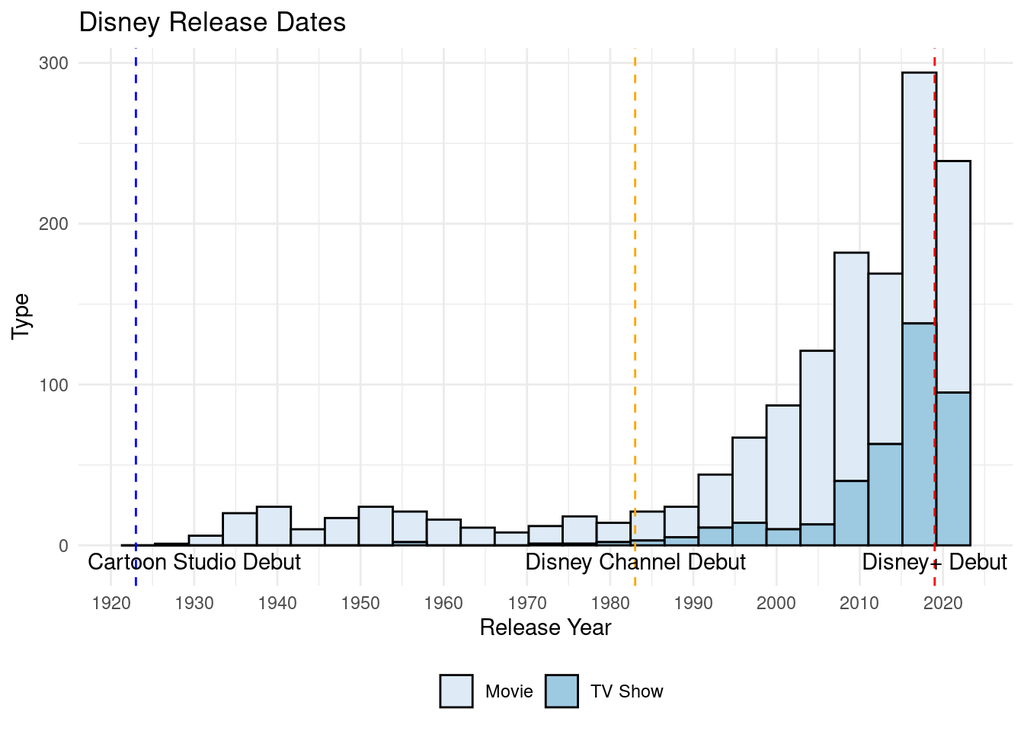

```r
ggplot(ratings, aes(release_year, fill = type)) +
    geom_histogram(bins = 25, color = "black") +
    scale_fill_brewer() +
    theme_minimal() +
    theme(legend.position = "bottom") +
    theme(legend.title=element_blank()) +
  geom_vline(xintercept = c(1923,1983,2019), color = c("Blue", "Orange", "Red"), linetype = "dashed") +
  annotate("text", x = 1930, y = -10, label =  "Cartoon Studio Debut") +
annotate("text", x = 1983, y = -10, label = "Disney Channel Debut") +
annotate("text", x = 2019, y = -10, label = "Disney+ Debut") +
    labs(title = "Disney Release Dates", x = "Release Year", y = "Type") +
scale_x_continuous(breaks = seq(from = 1920, to = 2030, by = 10))
```

#### Release Years by Program Type—Summary

Create a quantitative summary of `release_year` by program `type` that shows the oldest release year, the median release year, and the newest release year for each group of programs (i.e., movies and TV shows).

```r
ratings_summary <- ratings %>%
  group_by(type) %>%
  summarise(oldest = min(release_year),
            median = median(release_year),
            newest = max(release_year))
```

[output not shown]

### Analysis 2: Disney Content & Ratings

**This analysis uses Data set #1.**

Create a horizontal bar plot to show the frequencies of the various `rating` categories for programs on Disney+ (i.e., use `y =` rather than `x =` for the variable you are plotting). **You will need to remove a couple `NA` values before plotting** Facet by `type` so that you have side-by-side plots for the two different program types. Add an informative title and axis labels, as well as at least two other types of useful formatting.

use is.na

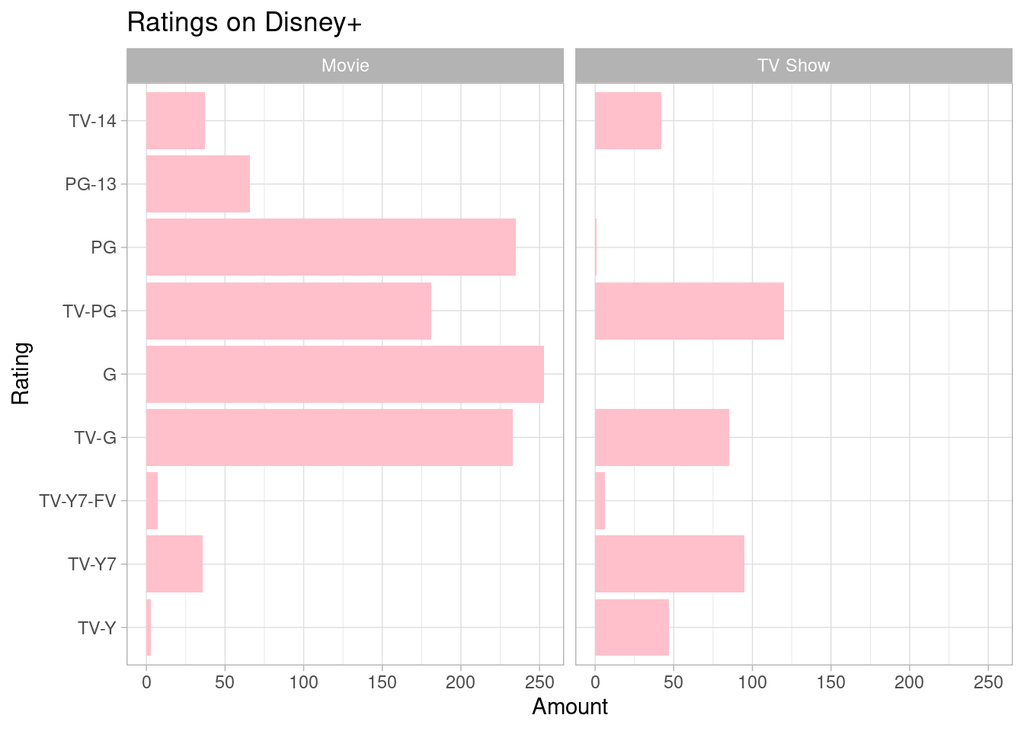

```r
ratingsorderNoNA <- filter(ratings, !is.na(rating))

ggplot(ratingsorderNoNA, aes(y = rating)) +
    geom_bar(fill = "pink") +
scale_fill_brewer(palette = "Pastel2") +
    labs(title = "Ratings on Disney+", x = "Amount", y = "Rating") +
    theme_light()+
    theme(legend.position = "none") +
    facet_wrap(~type)
```

### Analysis 3: Content on Different Services

**This analysis uses Dataset #2.**

#### Quantity of Content by Service

Create an appropriate bar plot to show the number of TV shows offered by the four streaming services. Include an informative title and axis labels. Add at least two other types of formatting to enhance the effectiveness and/or appearance of your plot (e.g., themes, colors, etc).

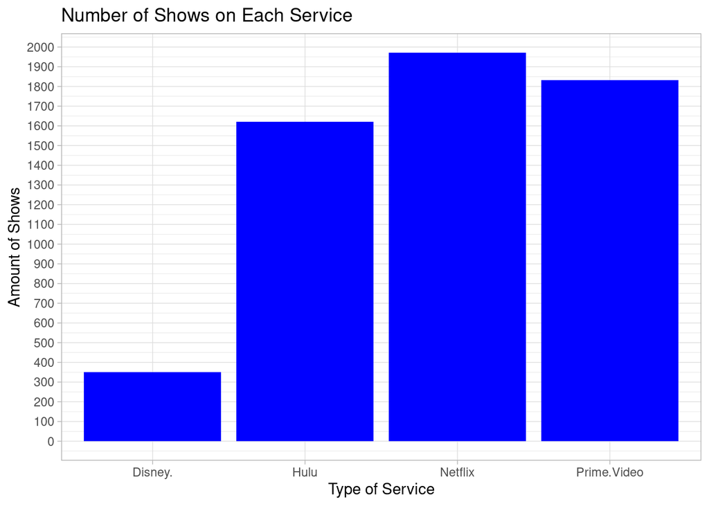

```r
ggplot(tv_streaming, aes(x = Service)) +
    geom_bar(fill = "blue") +
    labs(title = "Number of Shows on Each Service", x = "Type of Service", y = "Amount of Shows") + theme_light()+
  scale_y_continuous(breaks=seq(0,2000,by=100))
```

#### Quality of Content by Service

Create an appropriate plot to compare either IMDB or Rotten Tomatoes ratings for content on the streaming services. Include an informative title and axis labels. Add at least two other types of formatting to enhance your plot (e.g., themes, colors, etc).

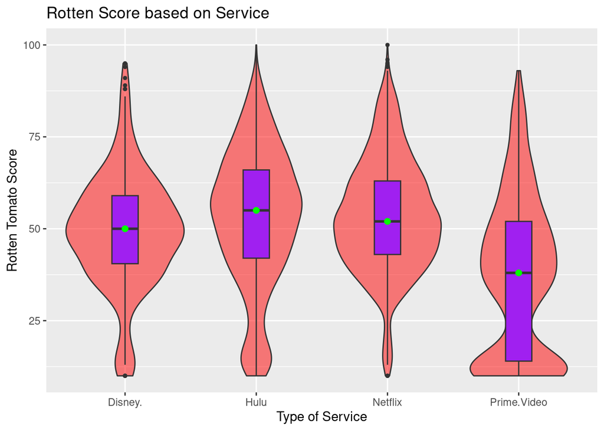

```r
ggplot(tv_streaming, aes(Service, rottenscore)) +
  geom_violin(fill = "Red", alpha = .5) +
  geom_boxplot(width = .2, fill = "purple", outlier.size = 1) +
 labs(title = "Rotten Score based on Service", x = "Type of Service", y = "Rotten Tomato Score") + stat_summary(fun.y=median, geom="point", size=2, color="green")
```

### Analysis 4: Choose Your Own Plot!

**This plot uses either dataset.**

Create one other plot of your choice using either data set to explore a question of interest. It should not be too similar to any of the plots you made above. You are welcome to perform additional manipulations on the data, if needed. Add an appropriate title and axis labels, as well as any other necessary formatting to make your plot clear and effective.

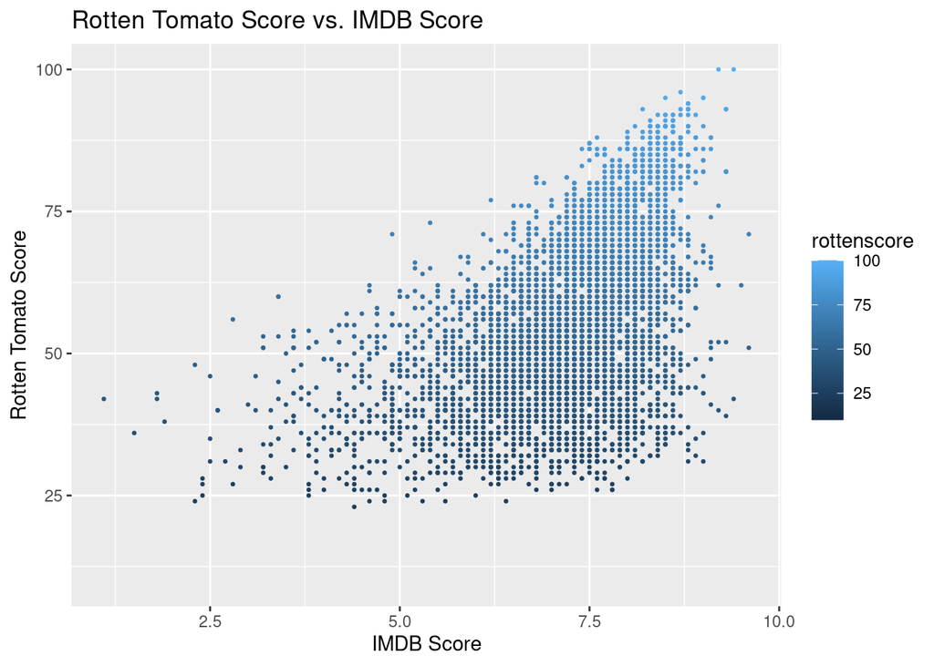

```r
ggplot(tv_streaming, aes(IMDBscore, rottenscore, color = rottenscore)) +
    geom_point(size = .5) +
    labs(title = "Rotten Tomato Score vs. IMDB Score", x = "IMDB Score", y = "Rotten Tomato Score")
```

## Questions

**Question 1:** Based on your plots, make five informational statements or comparisons regarding the Disney+ streaming service.

**ANSWER**

**Question 2:** What other data would you like to have, or which existing variables would you like to see transformed, if you were going to do further explorations or visualizations? Give at least two examples.

**ANSWER**

We would’ve liked to see the duration variable in the ratings order data set transformed into something numerical rather than just having it as a character value. We also would’ve liked to see data from at least one more streaming service such as Paramount+ or HBO Max.

**Question 3:** Explain the rationale behind the choices you made with regard to plot type, formatting, and so on, when you created Analysis 4. What motivated your decisions with regard to this plot?

**ANSWER**

We wanted to see how strong the correlation was between shows with high IMDB scores vs. shows with high rotten tomato score, and if a show with a higher IMBD score meant for certain that it’d have a higher rotten tomato score. We also added the color aesthetic and changed the size of the data points to make the graph easier to read, since many of the points were jumbled together.